# Zadanie 3,5

Witold Kociński, Aleksander Panimash

19 kwietnia 2017

# Uwzględnienie pozycji w analizie wyników testów

**Uwaga:** Dla przejrzystości rozważamy 5 krajóW:

- Finlandia
- Japonia
- Polska
- Stany Zjednoczone
- Hiszpania

*Problem:* Czu pozycja pytań ma wpływ na wyniki testu oraz na czas rozwiązywania zadań? Jeśli tak to jaki?

## 1. Zależność wyników od pozycji zadań

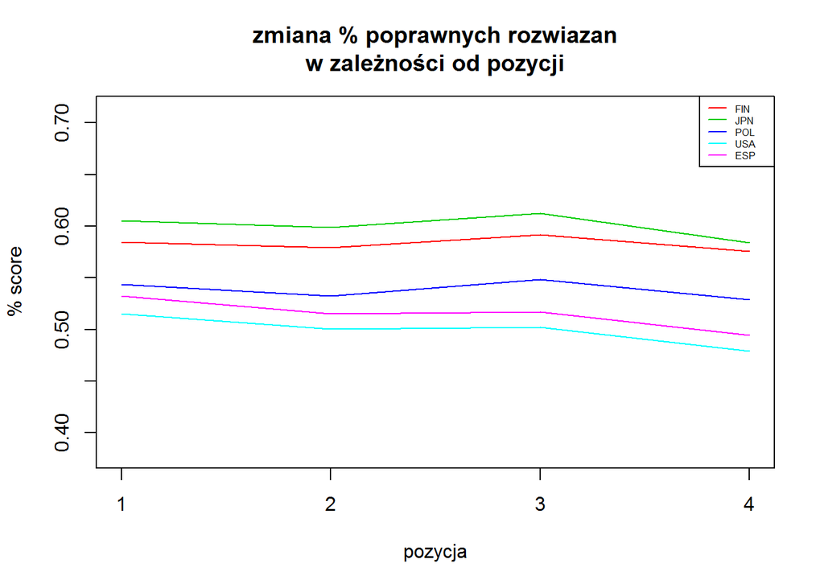

Poniższy wykres sugeruje, że wyniki nie są monotonicznie zależne od pozycji zadnia. Ponadto możemy zauwazyć, że dla wszytskich krajów zadani znajdujące się na pozycji nr. 3 średnio idą lepiej niż zadani sąsiednie.

## 2. Zależność czasu rozwiązania od pozycji zadań

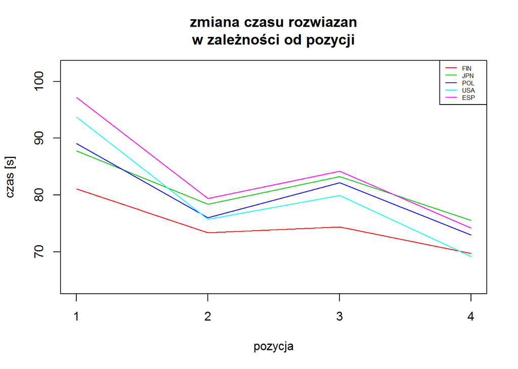

Wykres ważonej średniej czasu rozwiązań zadań na każdej z pozycji potwierdza intuicję, że im bliżej końc testu studenci pod wpływem stresu/zmęczenia poświecają na ostatnie zadania mniej czasu. Poniżej prezentujemy wyniku testu Kruskalla-Wallisa na zależność czasu rozwiązań od pozycji zadania dla danego kraju.

```
## kraj:  FIN       p.wartosc:  0
## kraj:  JPN       p.wartosc:  4.507924e-278
## kraj:  POL       p.wartosc:  0
## kraj:  USA       p.wartosc:  0
## kraj:  ESP       p.wartosc:  0
```

Poniżej badamy czy dla ustalonej pozycji dowolne dwa wybrane powyżej kraje isotnie rozwiązują zdania w różnym czasie. Ze względu na porównania wielokrotne stosujemy poprawkę Bonferroniego.

```
##      kraj 1      kraj 2      wartosc               pozycja
## [1,] "FIN      " "ESP      " "0"                   "1"
## [2,] "JPN      " "ESP      " "0"                   "1"
## [3,] "POL      " "USA      " "0.00191623615945706" "2"
```

## 3. Jak pozycja danego zadania wpływa na jego trudność

Możemy zastanawiać się jak na ‘łatwość’ zadania (tj. procent poprawnych odpowiedzi na nie udzielonych) wpływa jego umiejscowienie w teście. Poniżej dla każdego kraju wybrane zostały zadania z każdej kategori (R/M/S), które okazały się średnio najłatwiejsze bądź najtrudniejsze. Następnie dla każdego z nich policzony został procent poprawnych odpowiedzi zależnie od pozycji zadania.

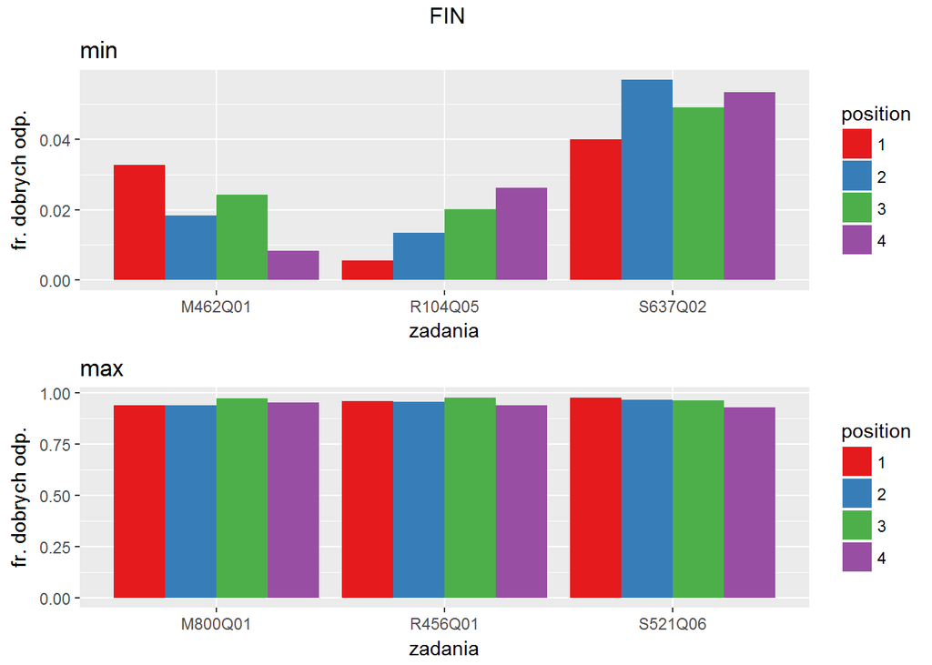

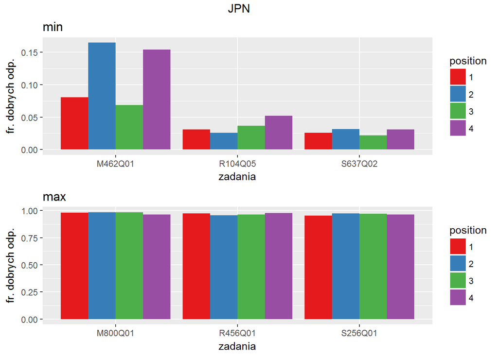

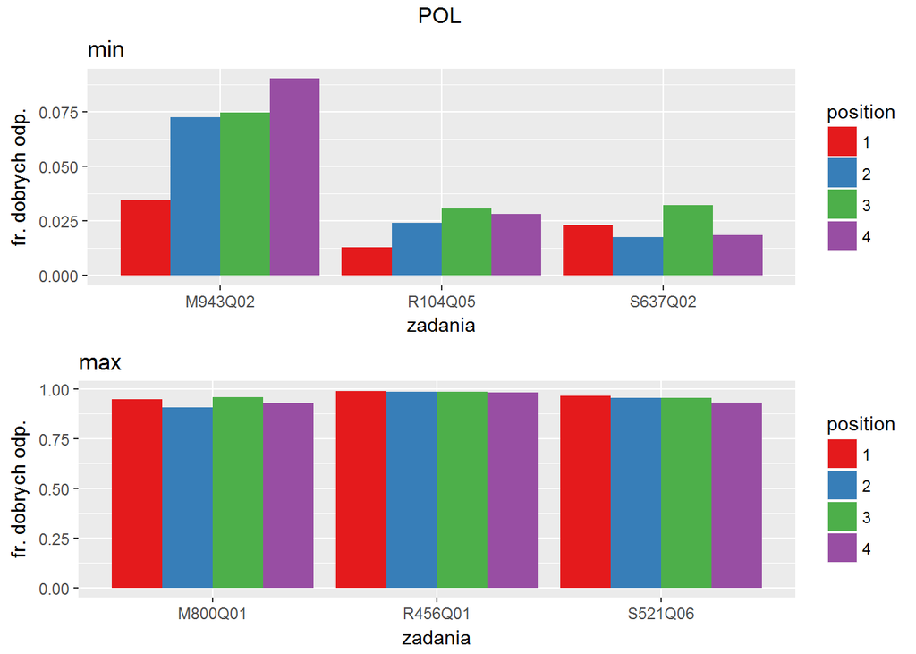

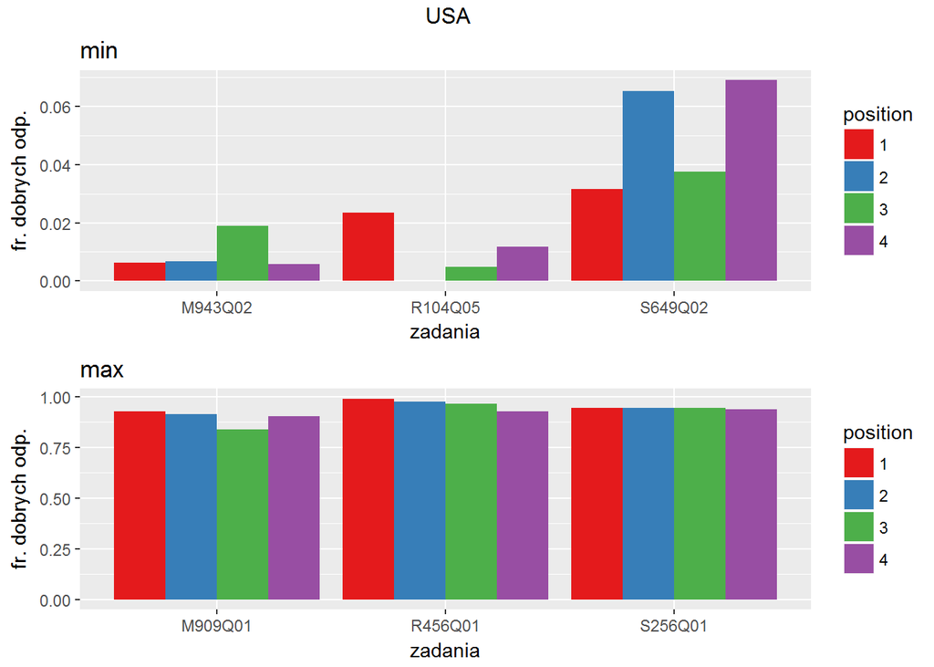

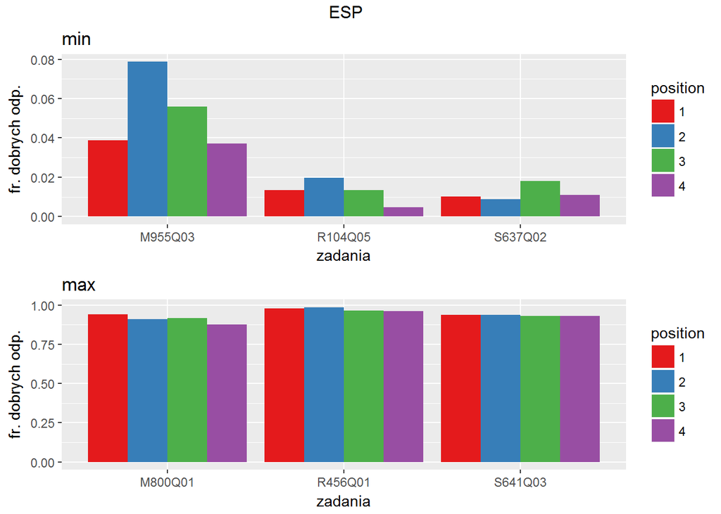

Powyższe wykresy sugerują, że dla wybranych państw i zadań w danym państwie rozwiązywanych najlepiej kolejnośc nie ma znaczenia. Z kolei dla zadań ‘najtrudniejszych’ zauważamy, znaczące wahania ilości poprawnych odpowiedzi jednak brak zauważalnego tredndu wspoólnego dla wszystkich krajóW bądź typów pytań.